# Produced for Data Analytics and Story Telling (DCU)

Author

Aman Singh Parihar - A00050767

Published

April 12, 2026

```python
from google.colab import drive
drive.mount('/content/drive')
```

```python
# ── Install dependencies (Google Colab) ──────────────────────────────────────
!pip install polars plotnine geopandas pyarrow matplotlib geodatasets -q
```

```python
# ── Imports ──────────────────────────────────────────────────────────────────
import polars as pl
import geopandas as gpd
import matplotlib.pyplot as plt
import warnings
warnings.filterwarnings('ignore')

from plotnine import (
    ggplot, aes, geom_bar, geom_point, geom_line, geom_map,
    geom_text, geom_col, geom_smooth,
    scale_fill_manual, scale_fill_gradient, scale_fill_gradient2,
    scale_color_manual, scale_x_continuous, scale_y_continuous,
    scale_color_brewer, scale_fill_brewer, scale_color_gradient,
    labs, theme, theme_minimal, theme_classic, theme_bw,
    element_text, element_rect, element_line, element_blank,
    coord_flip, facet_wrap, guides, guide_legend,
    position_dodge, position_stack
)

print('All imports successful!')
```

```
All imports successful!
```

## Load Data

```python
# ── Mount Google Drive & Load Data ───────────────────────────────────────────
from google.colab import drive
drive.mount('/content/drive')

ind1 = pl.read_csv('/content/drive/MyDrive/unicef_indicator_1.csv')
ind2 = pl.read_csv('/content/drive/MyDrive/unicef_indicator_2.csv')
meta = pl.read_csv('/content/drive/MyDrive/unicef_metadata.csv')

print(f'Indicator 1 shape: {ind1.shape}')
print(f'Indicator 2 shape: {ind2.shape}')
print(f'Metadata shape:    {meta.shape}')
```

```
Indicator 1 shape: (216, 14)
Indicator 2 shape: (625, 14)
Metadata shape:    (13715, 15)
```

## Introduction

Welcome to a data-driven exploration of **children’s welfare across the globe**. This report investigates two critical UNICEF indicators:

- **Indicator 1:** Percentage of children suffering five or more simultaneous deprivations
- **Indicator 2:** Uptake of zinc treatment for diarrhoea among children under 5

Diarrhoea kills hundreds of thousands of under-5s each year, yet zinc supplementation — simple and cheap — cuts its duration and severity significantly. Multidimensional child poverty remains concentrated in regions least equipped to address it. Together, these indicators reveal where children are most vulnerable and where progress is stalling.

## 1. Global Child Deprivation: A World Map

Children suffering from **five simultaneous deprivations** represent the most severely disadvantaged group. The map shows each country’s most recently recorded deprivation rate. Darker shades indicate higher proportions of children in acute deprivation.

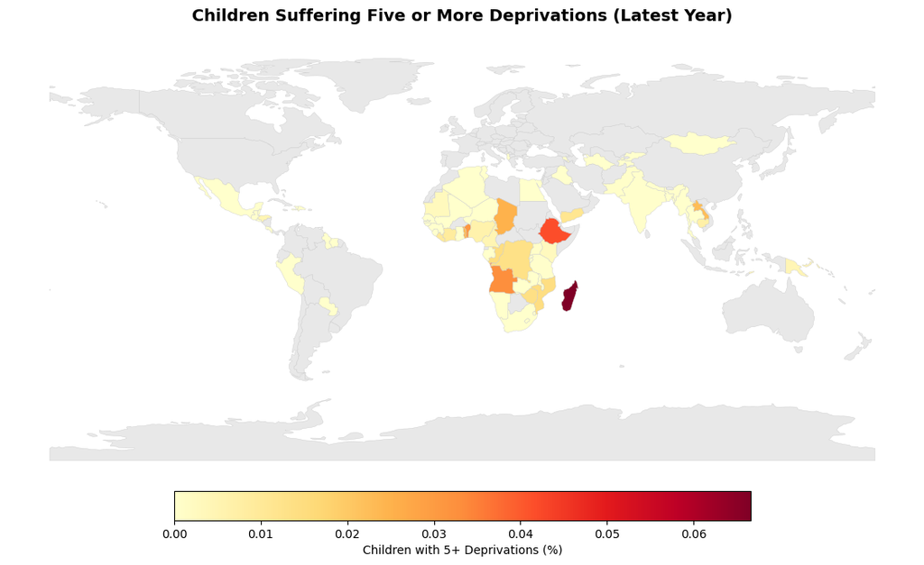

```python
# ── 1. World Map – Child Deprivation ─────────────────────────────────────────

dep_latest = (
    ind1
    .filter(pl.col('sex') == 'Total')
    .sort('time_period', descending=True)
    .unique(subset=['country'], keep='first')
    .select(['alpha_3_code', 'obs_value'])
    .rename({'obs_value': 'deprivation_pct'})
)

# Load world geometry from Natural Earth via URL (geopandas.datasets deprecated)
NE_URL = (
    'https://raw.githubusercontent.com/nvkelso/natural-earth-vector/'
    'master/geojson/ne_110m_admin_0_countries.geojson'
)
world = gpd.read_file(NE_URL)
# ADM0_A3 is the most complete ISO-A3 equivalent in Natural Earth data
world = world.rename(columns={'ADM0_A3': 'alpha_3_code'})
dep_pd = dep_latest.to_pandas()
world_merged = world.merge(dep_pd, on='alpha_3_code', how='left')

fig, ax = plt.subplots(1, 1, figsize=(14, 7))

world_merged[world_merged['deprivation_pct'].isna()].plot(
    ax=ax, color='#e8e8e8', edgecolor='#cccccc', linewidth=0.3
)
world_merged.dropna(subset=['deprivation_pct']).plot(
    column='deprivation_pct',
    cmap='YlOrRd',
    linewidth=0.3,
    edgecolor='#cccccc',
    ax=ax,
    legend=True,
    legend_kwds={
        'label': 'Children with 5+ Deprivations (%)',
        'orientation': 'horizontal',
        'shrink': 0.5,
        'pad': 0.02
    }
)

ax.set_title(
    'Children Suffering Five or More Deprivations (Latest Year)',
    fontsize=14, fontweight='bold', pad=15
)
ax.set_axis_off()
plt.tight_layout()
plt.show()
```

## 2. Zinc Treatment Uptake by Gender

Zinc treatment is a low-cost, high-impact intervention for child diarrhoea. The chart examines the **top 15 countries by treatment uptake**, split by sex to reveal any gender-based access gaps.

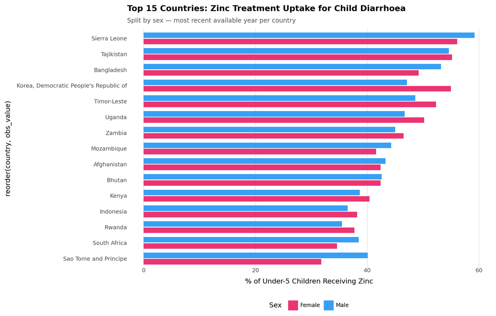

```python
# ── 2. Bar Chart – Zinc Treatment by Country & Sex ───────────────────────────

zinc_gender = (
    ind2
    .filter(pl.col('sex').is_in(['Male', 'Female']))
    .sort('time_period', descending=True)
    .unique(subset=['country', 'sex'], keep='first')
)

top15_countries = (
    zinc_gender
    .group_by('country')
    .agg(pl.mean('obs_value').alias('avg'))
    .sort('avg', descending=True)
    .head(15)
    .select('country')
)

zinc_top15 = zinc_gender.join(top15_countries, on='country', how='inner')

(
    ggplot(zinc_top15.to_pandas(), aes(x='reorder(country, obs_value)', y='obs_value', fill='sex'))
    + geom_col(position=position_dodge(width=0.8), width=0.7, alpha=0.9)
    + scale_fill_manual(values={'Male': '#2196F3', 'Female': '#E91E63'})
    + coord_flip()
    + labs(
        title='Top 15 Countries: Zinc Treatment Uptake for Child Diarrhoea',
        subtitle='Split by sex — most recent available year per country',
        x=None,
        y='% of Under-5 Children Receiving Zinc',
        fill='Sex'
    )
    + theme_minimal()
    + theme(
        figure_size=(11, 7),
        plot_title=element_text(size=13, weight='bold'),
        plot_subtitle=element_text(size=10, color='#555555'),
        legend_position='bottom',
        panel_grid_major_y=element_blank(),
        panel_grid_minor=element_blank(),
        axis_text=element_text(size=9)
    )
)
```

> **Key insight:** In top-performing countries, zinc uptake frequently exceeds 40–50%, but gender differences are generally small — access barriers are country-level rather than sex-linked. Inter-country variation is stark, pointing to disparate health system capacity.

## 3. Trend Over Time: Zinc Treatment (Selected Countries)

The time series tracks zinc treatment uptake across countries with multiple data points, revealing whether coverage is improving, stagnating, or regressing.

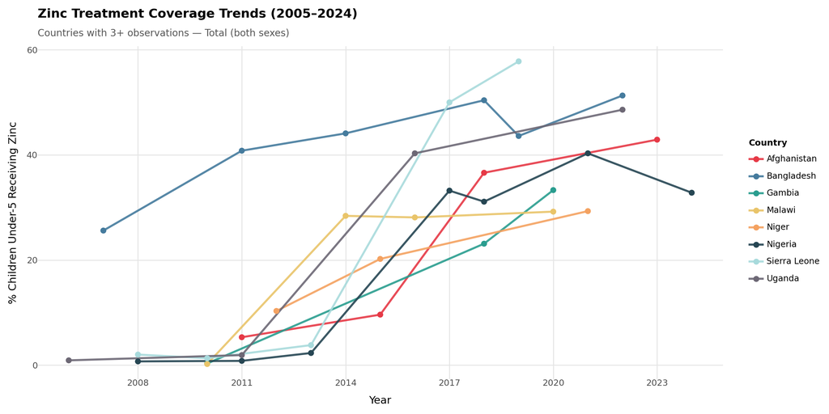

```python
# ── 3. Time Series – Zinc Treatment Trend ────────────────────────────────────

zinc_trend = (
    ind2
    .filter(pl.col('sex') == 'Total')
    .group_by('country')
    .agg(pl.count('time_period').alias('n_obs'))
    .filter(pl.col('n_obs') >= 3)
    .join(
        ind2.filter(pl.col('sex') == 'Total').select(['country', 'time_period', 'obs_value']),
        on='country',
        how='inner'
    )
    .sort('time_period')
)

top8 = (
    zinc_trend
    .group_by('country')
    .agg(pl.mean('obs_value').alias('avg'))
    .sort('avg', descending=True)
    .head(8)
    .select('country')
)

zinc_trend_top8 = zinc_trend.join(top8, on='country', how='inner')

palette = [
    '#E63946', '#457B9D', '#2A9D8F', '#E9C46A',
    '#F4A261', '#264653', '#A8DADC', '#6D6875'
]

(
    ggplot(zinc_trend_top8.to_pandas(), aes(x='time_period', y='obs_value', color='country'))
    + geom_line(size=1.2, alpha=0.9)
    + geom_point(size=2.5)
    + scale_color_manual(values=palette)
    + scale_x_continuous(breaks=list(range(2005, 2025, 3)))
    + labs(
        title='Zinc Treatment Coverage Trends (2005–2024)',
        subtitle='Countries with 3+ observations — Total (both sexes)',
        x='Year',
        y='% Children Under-5 Receiving Zinc',
        color='Country'
    )
    + theme_minimal()
    + theme(
        figure_size=(12, 6),
        plot_title=element_text(size=13, weight='bold'),
        plot_subtitle=element_text(size=10, color='#555555'),
        legend_position='right',
        legend_title=element_text(size=9, weight='bold'),
        panel_grid_minor=element_blank(),
        axis_text=element_text(size=9)
    )
)
```

> **Key insight:** Coverage trajectories vary considerably. Some countries show steady upward trends, suggesting effective scale-up programmes; others plateau or decline — likely reflecting funding gaps, supply chain issues, or post-COVID health priority shifts.

## 4. GDP Per Capita vs. Child Deprivation

Does national wealth correlate with child welfare outcomes? Each country is positioned by **GDP per capita** against its **child deprivation rate**, with population as bubble size.

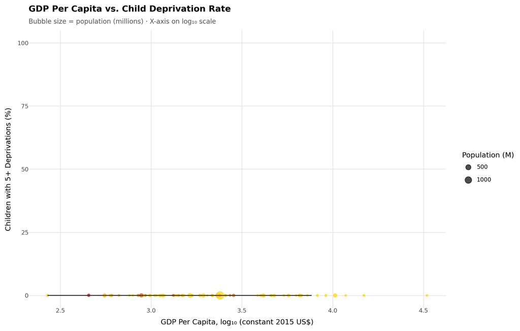

```python
# ── 4. Scatter – GDP per Capita vs Child Deprivation ─────────────────────────

dep_for_scatter = (
    ind1
    .filter(pl.col('sex') == 'Total')
    .sort('time_period', descending=True)
    .unique(subset=['country'], keep='first')
    .select(['alpha_3_code', 'country', 'obs_value', 'time_period'])
    .rename({'obs_value': 'deprivation_pct'})
)

meta_latest = (
    meta
    .sort('year', descending=True)
    .unique(subset=['alpha_3_code'], keep='first')
    .select([
        'alpha_3_code',
        pl.col('GDP per capita (constant 2015 US$)').alias('gdp_pc'),
        pl.col('Population, total').alias('population'),
        pl.col('Life expectancy at birth, total (years)').alias('life_exp')
    ])
)

scatter_df = (
    dep_for_scatter
    .join(meta_latest, on='alpha_3_code', how='inner')
    .drop_nulls(subset=['gdp_pc', 'deprivation_pct', 'population'])
    .with_columns([
        (pl.col('population') / 1_000_000).alias('pop_m'),
        pl.col('gdp_pc').log(base=10).alias('log_gdp')
    ])
)

(
    ggplot(scatter_df.to_pandas(), aes(x='log_gdp', y='deprivation_pct', size='pop_m', color='deprivation_pct'))
    + geom_point(alpha=0.7)
    + geom_smooth(method='lm', color='#333333', fill='#cccccc', alpha=0.2, size=0.8)
    + scale_color_gradient(low='#ffd700', high='#cc0000')
    + guides(color='none')
    + scale_y_continuous(limits=(0, 100))
    + labs(
        title='GDP Per Capita vs. Child Deprivation Rate',
        subtitle='Bubble size = population (millions) · X-axis on log₁₀ scale',
        x='GDP Per Capita, log₁₀ (constant 2015 US$)',
        y='Children with 5+ Deprivations (%)',
        size='Population (M)'
    )
    + theme_minimal()
    + theme(
        figure_size=(11, 7),
        plot_title=element_text(size=13, weight='bold'),
        plot_subtitle=element_text(size=10, color='#555555'),
        panel_grid_minor=element_blank(),
        legend_position='right',
        axis_text=element_text(size=9)
    )
)
```

## 5. Life Expectancy in Top 20 Countries by Zinc Treatment Uptake

Do countries with high zinc treatment uptake also tend to have longer life expectancies? The chart below looks at the top 20 countries by zinc coverage and maps their life expectancy at birth, with bar colour indicating how high their zinc uptake actually is.

```
(20, 4)
```

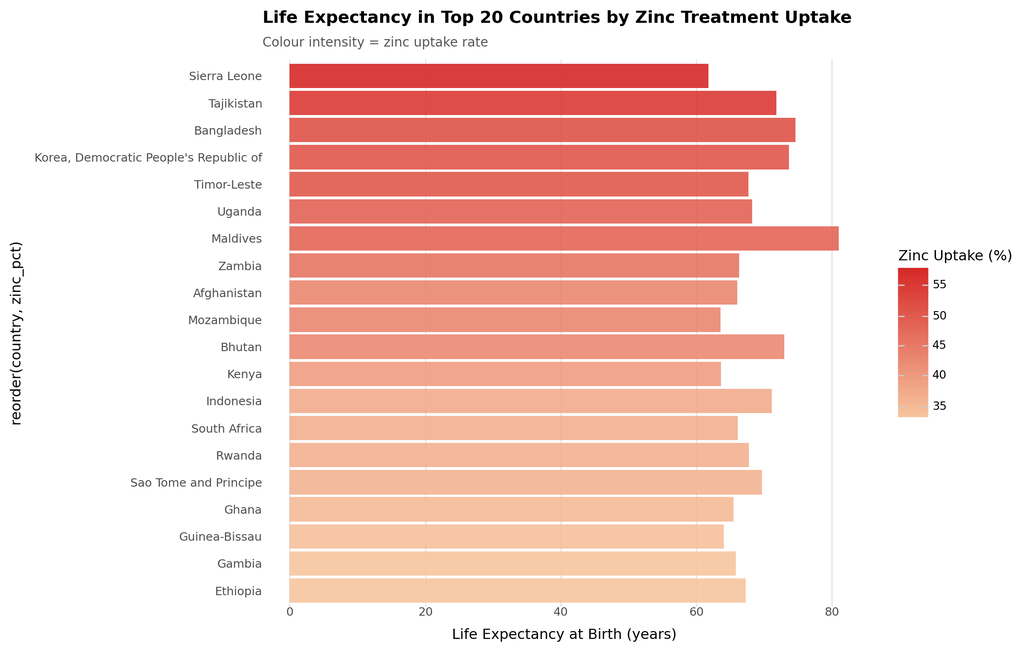

```python
top20_zinc = (
    ind2
    .filter(pl.col('sex') == 'Total')
    .sort('time_period', descending=True)
    .unique(subset=['alpha_3_code'], keep='first')
    .sort('obs_value', descending=True)
    .head(20)
    .select(['alpha_3_code', 'country', 'obs_value'])
    .rename({'obs_value': 'zinc_pct'})
)

meta_le = (
    meta
    .drop_nulls(subset=['Life expectancy at birth, total (years)'])
    .sort('year', descending=True)
    .unique(subset=['alpha_3_code'], keep='first')
    .select([
        'alpha_3_code',
        pl.col('Life expectancy at birth, total (years)').alias('life_exp')
    ])
)

bar_df = top20_zinc.join(meta_le, on='alpha_3_code', how='inner').to_pandas()
print(bar_df.shape)

(
    ggplot(bar_df, aes(x='reorder(country, zinc_pct)', y='life_exp', fill='zinc_pct'))
    + geom_col(alpha=0.9)
    + scale_fill_gradient(low='#f7c59f', high='#d62828')
    + coord_flip()
    + labs(
        title='Life Expectancy in Top 20 Countries by Zinc Treatment Uptake',
        subtitle='Colour intensity = zinc uptake rate',
        x=None,
        y='Life Expectancy at Birth (years)',
        fill='Zinc Uptake (%)'
    )
    + theme_minimal()
    + theme(
        figure_size=(11, 7),
        plot_title=element_text(size=13, weight='bold'),
        plot_subtitle=element_text(size=10, color='#555555'),
        panel_grid_major_y=element_blank(),
        panel_grid_minor=element_blank(),
        axis_text=element_text(size=9)
    )
)
```

## > **Key insight:** High zinc uptake does not automatically translate to high life expectancy. Several countries with strong zinc coverage still report relatively low life expectancy figures, reflecting the reality that zinc programmes are often deployed precisely where diarrhoeal disease burden is highest — in lower-income, higher-mortality settings. The chart reinforces that targeted interventions can be effective even within fragile health systems.

## Conclusion

The path to improvement demands country-specific strategies, sustained funding for low-cost interventions like zinc, and investment in the data infrastructure needed to monitor progress honestly.

*Data sourced from UNICEF. Analysis produced using Python (Polars, Plotnine, GeoPandas).*